# Parental loss from drugs and firearms in the US

A matrix kinship model approach

Benjamin Schlüter

## Matrix Kinship model

Kin dynamics: parents of Focal

- Cause-specific (drugs, firearms, other) mortality (Caswell, Margolis, and Verdery 2023)
  - Track parents’ deaths by age and cause
- Two-sex: male fertility = shifted female fertility (Schoumaker 2019)
- Time-variant rates (2000-2020)

Model run independently on each ethnic group (Hispanic, Black, White)

## Parents dynamic - set-up

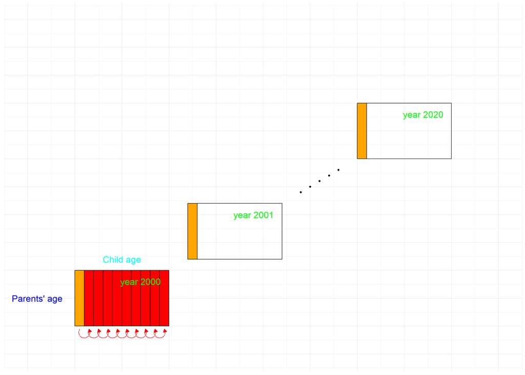

Boundary conditions

1. Stable population assumption in the years $\leq 2000$

2. $\boldsymbol{\pi_t} = \frac{\boldsymbol{F_t}(1,:)^T \circ \boldsymbol{n_t}}{||\boldsymbol{F_t}(1,:)^T \circ \boldsymbol{n_t}||}$

## Parents dynamic - projection

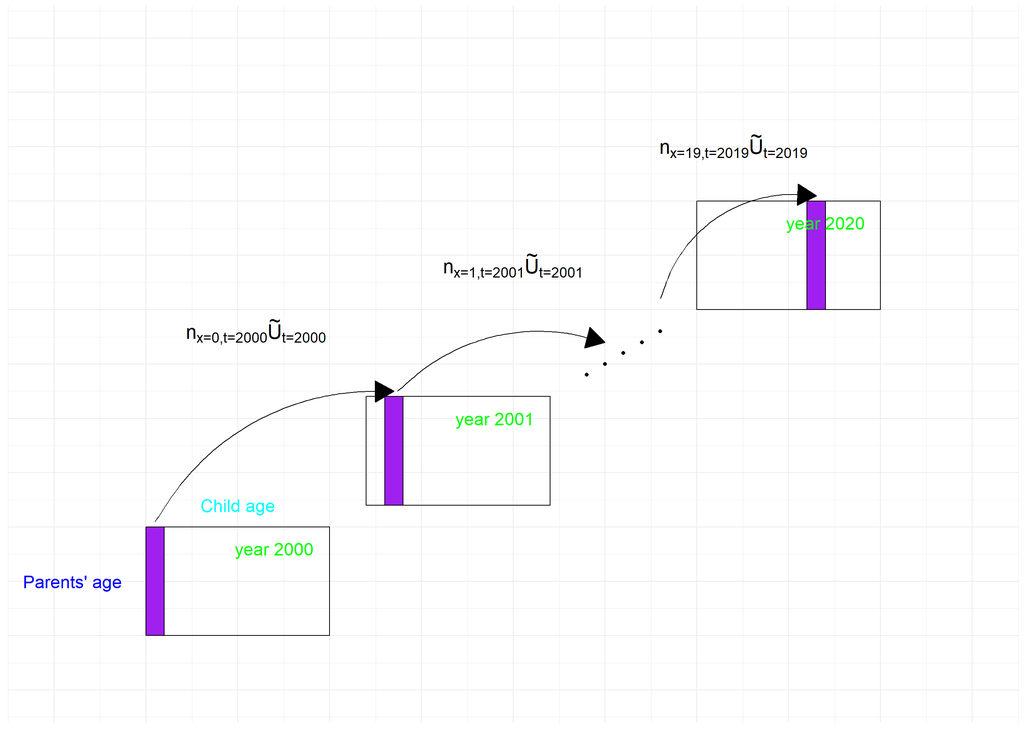

- Block-structured survival matrix ($\tilde{U}$)
- A block for cause-specific probabilities of dying ($\hat{M}$)
- $vec$ operator to stack alive and dead parents together

## Different perspectives

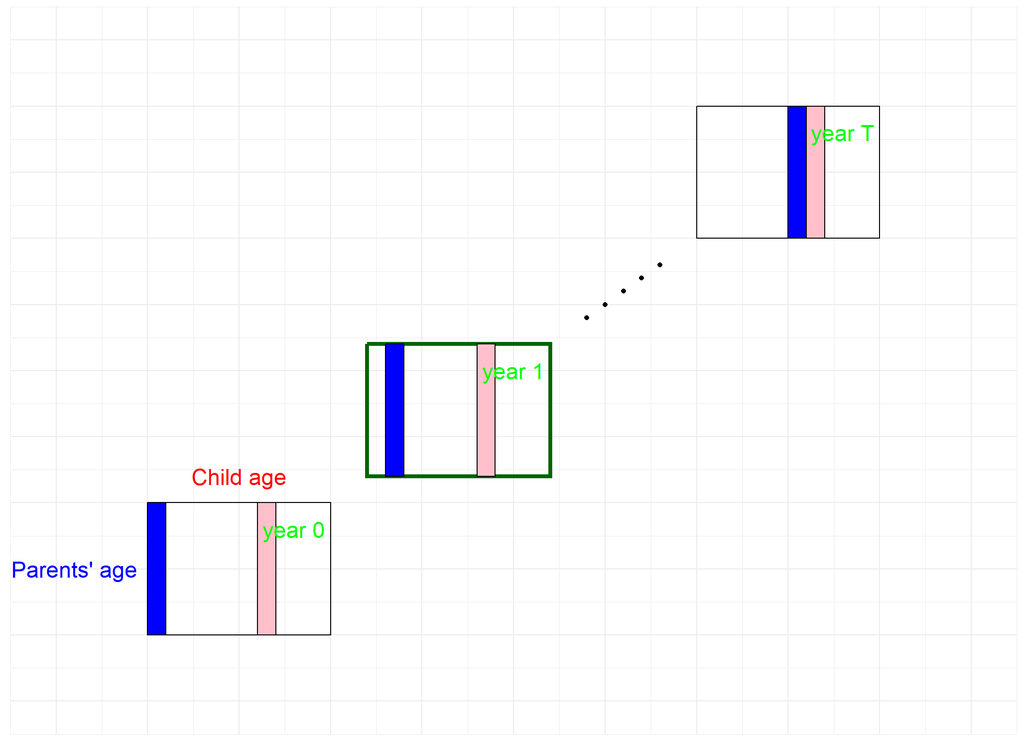

Period

- Proportion of parents dying from cause $i$
- Bereavement probability from cause $i$

Cohort

- Parental loss at population level (Alburez-Gutierrez, Kolk, and Zagheni 2021)

Age

## Parental loss (PL) at population level

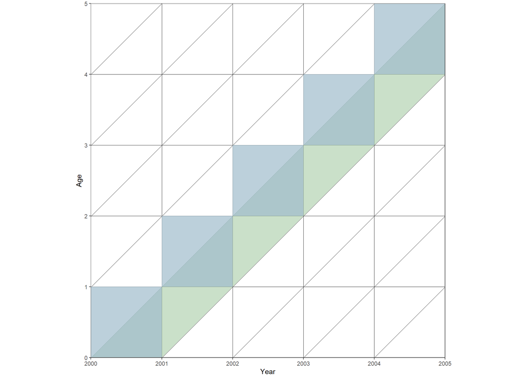

1. Fraction of cohort surviving ($l_{x}$) from period mortality rates, both sexes combined
2. Births ($B$)
3. Nber of deaths by cause at age $x$ ($d_D(x)$) from matrix kinship model

$PL_x = (l_{x}*B)*d_D(x)$

## Incorporating uncertainty

UN WPP:

- Use each posterior draw for each component in a cohort-component model

But

- Stochasticity in vital rates $\neq$ stochasticity from a small population (parents)

# Results

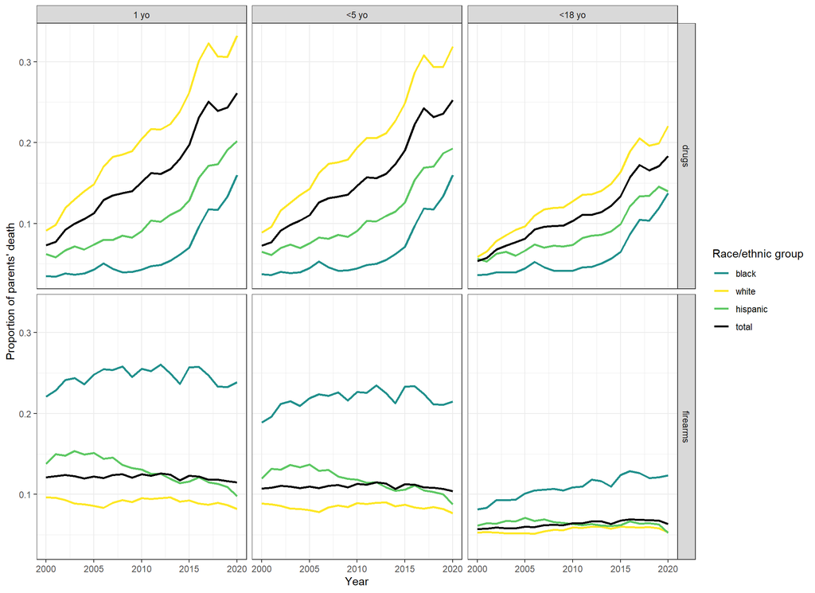

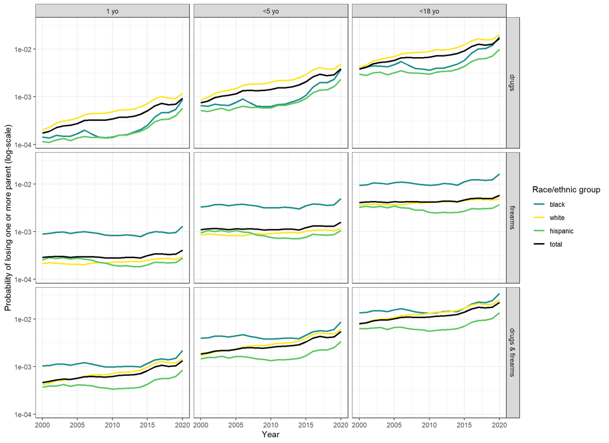

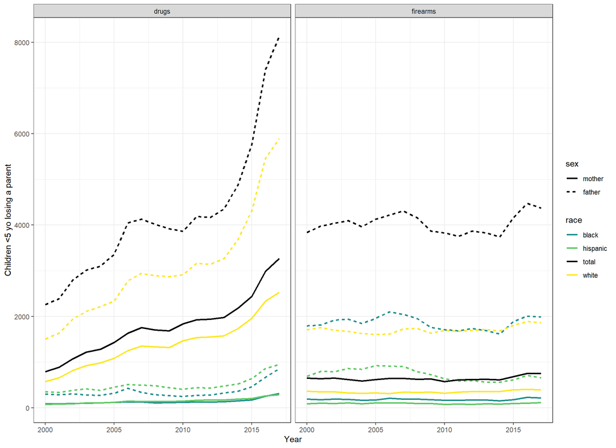

## References

Alburez-Gutierrez, Diego, Martin Kolk, and Emilio Zagheni. 2021. “Women’s Experience of Child Death over the Life Course: A Global Demographic Perspective.” *Demography* 58 (5): 1715–35.

Caswell, Hal, Rachel Margolis, and Ashton M Verdery. 2023. “The Formal Demography of Kinship v: Kin Loss, Bereavement, and Causes of Death.” *PAA Conference 2023*.

Schoumaker, Bruno. 2019. “Male Fertility Around the World and over Time: How Different Is It from Female Fertility?” *Population and Development Review* 45: 459–87. https://about.jstor.org/terms.